# Mapping of the Sustainable Food Production Group members

Ido Bar

23/06/2022

# Geographical mapping of group members

## Collect addresses

```r
# load required packages
pacman::p_load(tidyverse, ggmap, glue, geosphere, countrycode,
               pheatmap, scales, formattable, xml2, htmltab,
               leaflet, leafpm, paletteer)
# read in addresses from an excel
addresses <- readxl::read_excel("data/lab_members_addresses.xlsx") %>%
           mutate(first_name=sub(" .+", "", Name))
update_addresses <- TRUE
if (isTRUE(update_addresses)){
  # Get geodetails (up to 2,500 queries a day), otherwise use getGeo
  geodetails <- geocode(addresses$Address, output = "all", messaging=TRUE) # %>%
    # mutate(query=addresses$Address, formatted_address=snakecase::to_any_case(address, case = "title", parsing_option = -1))
  names(geodetails) <- addresses$Address
  geodetails %>% discard(~ .$status=="OK") %>% iwalk(~message(glue("Could not find details for {.y}")))
  # geodetails %>% keep(~ "university" %in% flatten_chr(.$results[[1]]$types)) %>%
  #   walk(~message(glue("{.} is a university")))

  results <- geodetails %>% keep(~ .$status=="OK") %>%
    # tibble(query=names(.)) %>% select(query) %>%
    imap_dfr(~tibble(query=.y, #country=sub(".+, *", "", .y),
    formatted_address=.x$results[[1]]$formatted_address,
    lat=.x$results[[1]]$geometry$location$lat,
    long=.x$results[[1]]$geometry$location$lng,
    Country=ifelse(isTRUE(.x$results[[1]]$address_components %>% map_lgl(~"country" %in% .$types) %>% any()),
                   .x$results[[1]]$address_components %>%
      keep(~ "country" %in% flatten_chr(.$types)) %>%
      flatten() %>% .$long_name, sub(".+, *", "", .y)))) %>%
    # country_code=.$results[[1]]$address_components %>%
    #   keep(~ "country" %in% flatten_chr(.$types)) %>%
    #   flatten() %>% .$short_name) %>%
    mutate(#query=names(geodetails %>% keep(~ .$status=="OK")),
           #Country = ifelse(is.null(Country), gsub(".+, *", "", formatted_address), Country),
           country_code=countrycode(Country, origin = 'country.name', destination = 'iso2c'))

    #
    # Country=.$results[[1]]$address_components %>%
    #   keep(~ "country" %in% flatten_chr(.$types)) %>%
    #   flatten() %>% .$long_name,
    # country_code=.$results[[1]]$address_components %>%
    #   keep(~ "country" %in% flatten_chr(.$types)) %>%
    #   flatten() %>% .$short_name,
    # status=.$status)) %>% mutate(query=names(geodetails %>% keep(~ .$status=="OK")))
  geo_df <- results %>%
  # geo_df <- addresses$Address %>% map_dfr(~getGeoDetails(.x)) %>%
    left_join(addresses, ., by=c("Address"="query")) %>%
    write_csv("data/lab_members_geodata.csv")
} else geo_df <- read_csv("data/lab_members_geodata.csv")
```

## Download flags

### Rectangular flags

Flags of the representative countries were downloaded to be used as map markers, both in rectangular and in a round emoji shape. The flags were downloaded from the [Google region flags](https://github.com/google/region-flags) GitHub repository and stored locally in `svg` format.

```r
# download flags
update_flags <- TRUE
walk(geo_df$country_code, ~{
  if (!file.exists(glue("img/flags/{.x}.svg")) | isTRUE(update_flags)) {
    download.file(glue('https://raw.githubusercontent.com/google/region-flags/gh-pages/svg/{.x}.svg'),
                       glue("img/flags/{.x}.svg"))
  } else {
    message(glue("File img/flags/{.x}.svg exists"))
    }
})
```

Note that I used the `walk()` function from the [purrr](https://purrr.tidyverse.org/) package to iterate over the filenames and download them, without returning any value. `walk()` is similar to the `map()` functions from the same package, which in turn provide functional programming alternatives to the `.apply()` functions in base R (see useful [purrr tutorial](https://jennybc.github.io/purrr-tutorial/ls01_map-name-position-shortcuts.html) and some [extra tips](https://www.hvitfeldt.me/blog/purrr-tips-and-tricks/#purrr-tips-and-tricks))

Special attention was needed when using the rectangular flags as markers, since each flag has a different height:width aspect ratio and a fixed width and height will distort some. The solution was to parse the `svg` files, which are basically in `xml` format, using the [xml2](https://xml2.r-lib.org/) package and calculate the aspect ratio from their width and height (see the function below and results in Table 1).

```r
getAspectRatioSVG <- function(img_file){
  require(xml2)
  # img_file=rect_flags$flag_file[3]
  img_info <- read_xml(img_file)
  aspect_ratio <- as.numeric(xml_attr(img_info, "width"))/as.numeric(xml_attr(img_info, "height"))
  if (length(aspect_ratio)>0 & is.numeric(aspect_ratio) & aspect_ratio>0) return(aspect_ratio)
  message(sprintf("File %s is not a valid SVG file or does not contain dimensions", img_file))
}
# specify a base marker height
base_height <- 15
# get flags aspect ratios from SVG files and calculate appropriate width
rect_flags <-  geo_df %>% select(country_code) %>%
  mutate(flag_file=glue("./img/flags/{country_code}.svg"),
         Ratio=map_dbl(flag_file, ~getAspectRatioSVG(.x)),
         flag_height=base_height, flag_width=base_height*Ratio)
```

Table 1: Aspect ratios of flags of selected countries

| country_code | flag_file | Ratio | flag_height | flag_width |
| --- | --- | --- | --- | --- |
| IL | ./img/flags/IL.svg | 1.375 | 15 | 20.625 |
| IN | ./img/flags/IN.svg | 1.500 | 15 | 22.500 |
| TH | ./img/flags/TH.svg | 1.500 | 15 | 22.500 |
| AU | ./img/flags/AU.svg | 2.000 | 15 | 30.000 |
| GB | ./img/flags/GB.svg | 2.000 | 15 | 30.000 |
| CN | ./img/flags/CN.svg | 1.500 | 15 | 22.500 |
| ID | ./img/flags/ID.svg | 1.500 | 15 | 22.500 |
| CA | ./img/flags/CA.svg | 2.000 | 15 | 30.000 |
| AU | ./img/flags/AU.svg | 2.000 | 15 | 30.000 |
| IN | ./img/flags/IN.svg | 1.500 | 15 | 22.500 |
| IR | ./img/flags/IR.svg | 1.750 | 15 | 26.250 |
| KE | ./img/flags/KE.svg | 1.500 | 15 | 22.500 |
| PK | ./img/flags/PK.svg | 1.500 | 15 | 22.500 |
| BD | ./img/flags/BD.svg | 1.667 | 15 | 25.000 |
| AU | ./img/flags/AU.svg | 2.000 | 15 | 30.000 |
| AU | ./img/flags/AU.svg | 2.000 | 15 | 30.000 |
| BD | ./img/flags/BD.svg | 1.667 | 15 | 25.000 |

> An alternative is to parse an online table containing the [flags aspect ratios](https://en.wikipedia.org/wiki/List_of_aspect_ratios_of_national_flags) from wikipedia (using htmltab package) and use the ratios to calculate the appropriate width for each flag, but it was more cumbersome and difficult to match countries just by name.

Once I have the dataframe with the flags information, I could iterate through it (this time using `pmap()` function from [purrr](https://purrr.tidyverse.org/)) to create an icon-set that I could use as markers in the map.

I then plotted the map with [leaflet](https://rstudio.github.io/leaflet/) package, using the `Esri.NatGeoWorldMap` tiles as a basemap, along with optional scale bar and distance/area measurement tool (the map is interactive, please play with it and hover over the markers).

```r
# Create a named list of icons/flags
flagIcons <-  rect_flags[c("flag_file", "flag_width", "flag_height")] %>%
  pmap(~makeIcon(..1, ..1,  iconWidth = ..2, iconHeight = ..3,
                 iconAnchorX = 0, iconAnchorY = 0)) %>%
  setNames(., rect_flags$country_code)
# make it an iconList
attr(flagIcons, "class") <- "leaflet_icon_set"

# Create the leaflet map
leaflet(geo_df) %>% addProviderTiles("Esri.NatGeoWorldMap") %>%
  addMarkers(popup = ~Name, label = ~Name,
             icon = ~flagIcons[country_code]) %>% # ~flagIcons[country_code]
  addScaleBar(position = "bottomright",
              options = scaleBarOptions(imperial = FALSE)) %>%
  addMeasure(primaryLengthUnit = "kilometers")
```

[interactive chart not shown]

### Emoji flags

An alternative visualisation was then used, trying to mimick the ggflags behaviour and use round flag emojis from the discontinued [EmojiOne Colour Font](https://github.com/eosrei/emojione-color-font) repository. In this case, I faced another challenge, trying to download just the `svg` files of the required flags out of the thousands of emojis that use their Unicodes as file names. This time, [Tim Whitlock’s blog](https://apps.timwhitlock.info) came to my rescue with an organised [Country-ISO3166-Unicode table](https://apps.timwhitlock.info/emoji/tables/iso3166) that I could parse with htmltab and construct the filenames to be downloaded (see Table 2).

```r
# Use round emoji flags as markers
round_flags <- htmltab("https://apps.timwhitlock.info/emoji/tables/iso3166") %>% as_tibble() %>%
  mutate(flag_file=tolower(sub(" ", "-",
                              gsub("U+", "", Unicode, fixed = TRUE)))) %>%
  select(Country=Name, country_code=ISO, flag_file) %>%
  inner_join(geo_df %>% select(country_code), .)

walk2(unique(round_flags$flag_file), unique(round_flags$country_code), ~{
  if (!file.exists(glue("img/emojis/{.y}.svg")) | isTRUE(update_flags)) {
    download.file(glue('https://raw.githubusercontent.com/eosrei/emojione-color-font/master/assets/emojione-svg/{.x}.svg'), glue("img/emojis/{.y}.svg"))
  } else {
    message(glue("File img/emojis/{.y}.svg exists"))
  }
      })
```

Table 2: Country name/ISO3166 code to Unicode conversion

| Country | country_code | flag_file |
| --- | --- | --- |
| Israel | IL | 1f1ee-1f1f1 |
| India | IN | 1f1ee-1f1f3 |
| Thailand | TH | 1f1f9-1f1ed |
| Australia | AU | 1f1e6-1f1fa |
| United Kingdom | GB | 1f1ec-1f1e7 |
| China | CN | 1f1e8-1f1f3 |
| Indonesia | ID | 1f1ee-1f1e9 |
| Canada | CA | 1f1e8-1f1e6 |
| Australia | AU | 1f1e6-1f1fa |
| India | IN | 1f1ee-1f1f3 |
| Iran | IR | 1f1ee-1f1f7 |
| Kenya | KE | 1f1f0-1f1ea |
| Pakistan | PK | 1f1f5-1f1f0 |
| Bangladesh | BD | 1f1e7-1f1e9 |
| Australia | AU | 1f1e6-1f1fa |
| Australia | AU | 1f1e6-1f1fa |
| Bangladesh | BD | 1f1e7-1f1e9 |

I plotted the same map as before, but using the emoji flags as markers and a different basemap (`Esri.WorldStreetMap`) for the interest (see complete list of available maps with `names(leaflet.providers::providers_loaded()$providers)` and a preview [here](http://leaflet-extras.github.io/leaflet-providers/preview/index.html) and note that some providers require registration or setting up an API key, see [details](https://github.com/leaflet-extras/leaflet-providers))

```r
base_height <- 20
# Create a named list of icons/flags
emojiIcons <- icons(glue("img/emojis/{round_flags$country_code}.svg"),
                    iconHeight = base_height, iconWidth = base_height,
                    iconAnchorX = 0, iconAnchorY = 0)

# Create the leaflet map
leaflet(geo_df) %>% addProviderTiles("Esri.WorldStreetMap") %>% # "Thunderforest.MobileAtlas", "USGS.USImageryTopo"
  addMarkers(popup = ~Name, label = ~Name,
             icon = emojiIcons) %>%
  addScaleBar(position = "bottomright",
              options = scaleBarOptions(imperial = FALSE)) %>%
  addMeasure(primaryLengthUnit = "kilometers")
```

[interactive chart not shown]

## Calculate distances

Once the map were plotted, I wanted to get a better and more accurate understanding of the distances between the hometowns of the group members. That was easily calculated using `distm()` function (with the `distVincentyEllipsoid` method) from the [geosphere](https://cran.r-project.org/web/packages/geosphere/index.html) package.

The distanced were then plotted using pheatmap package, that offers lots of customisation and annotation options (see [Dave Tang’s Blog](https://davetang.org/muse/2018/05/15/making-a-heatmap-in-r-with-the-pheatmap-package/) for usage examples), as well as plotting a dendrogram that shows the relatedness between members (Figure 1).

Figure 1: Heatmap showing the distance between group members and their corresponding clustering

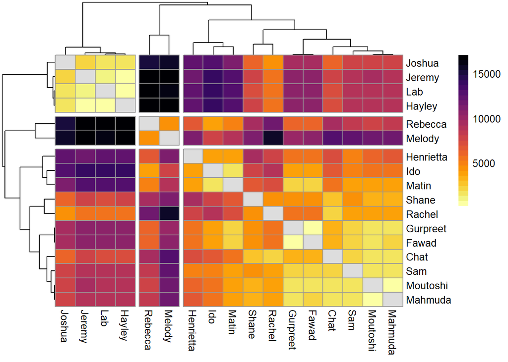

```r
# create distance matrix
dist_mat <- distm(geo_df[c('long','lat')], geo_df[c('long','lat')],
             fun=distVincentyEllipsoid)/1000
dimnames(dist_mat) <- list(geo_df$first_name, geo_df$first_name)
# set the diagonal to NA
dist_mat[dist_mat==0] <- NA

pheatmap(dist_mat, cutree_rows = 3,
         color = paletteer_c("viridis::inferno", 30, direction = -1),
         cutree_cols = 3)
```

The distances can actually be observed in the matrix:

Table 3: Distance matrix between group members

|  | Ido | Sam | Chat | Lab | Rebecca | Shane | Rachel | Melody | Jeremy | Gurpreet | Matin | Henrietta | Fawad | Moutoshi | Hayley | Joshua | Mahmuda |
| --- | --- | --- | --- | --- | --- | --- | --- | --- | --- | --- | --- | --- | --- | --- | --- | --- | --- |
| Ido | NA | 5077.29 | 6799.98 | 14112.45 | 3578.02 | 7844.83 | 8707.94 | 8047.88 | 14043.39 | 3722.12 | 1567.4 | 3747.22 | 3590.89 | 5290.7 | 14056.99 | 12935.33 | 5471.43 |
| Sam | 5077.29 | NA | 2074.64 | 9038.54 | 8271.78 | 4635.57 | 3631.53 | 12478.83 | 9002.53 | 2244.3 | 3627.38 | 5053.45 | 2161.29 | 1583.87 | 8983.21 | 7928.89 | 1597.8 |
| Chat | 6799.98 | 2074.64 | NA | 7395.54 | 9498.56 | 2948.84 | 2391.27 | 13076.3 | 7570.86 | 3233.33 | 5243.57 | 7105.02 | 3297.17 | 1615.02 | 7436.48 | 6141.91 | 1432.32 |
| Lab | 14112.45 | 9038.54 | 7395.54 | NA | 16585.69 | 7416.6 | 5415.45 | 16201.94 | 934.76 | 10617.51 | 12602.87 | 12511.5 | 10691.91 | 8988.22 | 443.46 | 1394.02 | 8802.61 |
| Rebecca | 3578.02 | 8271.78 | 9498.56 | 16585.69 | NA | 9172.64 | 11776.02 | 4473.11 | 17035.26 | 6301.02 | 4699 | 6827.92 | 6280.7 | 7886.06 | 16791.16 | 15192.1 | 8067.05 |
| Shane | 7844.83 | 4635.57 | 2948.84 | 7416.6 | 9172.64 | NA | 4481.52 | 11300.74 | 8008.88 | 4299.22 | 6393.72 | 9529.86 | 4489.1 | 3219.31 | 7665.21 | 6027.28 | 3122.57 |
| Rachel | 8707.94 | 3631.53 | 2391.27 | 5415.45 | 11776.02 | 4481.52 | NA | 15441.77 | 5388.36 | 5479.1 | 7243.36 | 7792.5 | 5495.43 | 3941.27 | 5351.87 | 4397.95 | 3770.37 |
| Melody | 8047.88 | 12478.83 | 13076.3 | 16201.94 | 4473.11 | 11300.74 | 15441.77 | NA | 17033.83 | 10284.73 | 9095.99 | 10897.6 | 10334.19 | 11633.21 | 16617.29 | 15770.02 | 11784.76 |
| Jeremy | 14043.39 | 9002.53 | 7570.86 | 934.76 | 17035.26 | 8008.88 | 5388.36 | 17033.83 | NA | 10797.65 | 12627.51 | 11937.33 | 10841.9 | 9185.66 | 494.03 | 2061.36 | 9002.16 |
| Gurpreet | 3722.12 | 2244.3 | 3233.33 | 10617.51 | 6301.02 | 4299.22 | 5479.1 | 10284.73 | 10797.65 | NA | 2170.46 | 5489.66 | 215.53 | 1629.29 | 10669.54 | 9324.63 | 1814.9 |
| Matin | 1567.4 | 3627.38 | 5243.57 | 12602.87 | 4699 | 6393.72 | 7243.36 | 9095.99 | 12627.51 | 2170.46 | NA | 4068.87 | 2028.46 | 3723.31 | 12586.36 | 11385.07 | 3904.07 |
| Henrietta | 3747.22 | 5053.45 | 7105.02 | 12511.5 | 6827.92 | 9529.86 | 7792.5 | 10897.6 | 11937.33 | 5489.66 | 4068.87 | NA | 5274.95 | 6312.83 | 12215.7 | 11988.41 | 6420.79 |
| Fawad | 3590.89 | 2161.29 | 3297.17 | 10691.91 | 6280.7 | 4489.1 | 5495.43 | 10334.19 | 10841.9 | 215.53 | 2028.46 | 5274.95 | NA | 1716 | 10729.66 | 9416 | 1900.5 |
| Moutoshi | 5290.7 | 1583.87 | 1615.02 | 8988.22 | 7886.06 | 3219.31 | 3941.27 | 11633.21 | 9185.66 | 1629.29 | 3723.31 | 6312.83 | 1716 | NA | 9044.35 | 7700.9 | 185.62 |
| Hayley | 14056.99 | 8983.21 | 7436.48 | 443.46 | 16791.16 | 7665.21 | 5351.87 | 16617.29 | 494.03 | 10669.54 | 12586.36 | 12215.7 | 10729.66 | 9044.35 | NA | 1654.21 | 8859.26 |
| Joshua | 12935.33 | 7928.89 | 6141.91 | 1394.02 | 15192.1 | 6027.28 | 4397.95 | 15770.02 | 2061.36 | 9324.63 | 11385.07 | 11988.41 | 9416 | 7700.9 | 1654.21 | NA | 7515.91 |
| Mahmuda | 5471.43 | 1597.8 | 1432.32 | 8802.61 | 8067.05 | 3122.57 | 3770.37 | 11784.76 | 9002.16 | 1814.9 | 3904.07 | 6420.79 | 1900.5 | 185.62 | 8859.26 | 7515.91 | NA |

Finally, we can look at the closest colleague of each member to decide who’s hometown is the most isolated (Table 4).

```r
# change into a long format
long_dist <- as.data.frame(dist_mat) %>% rownames_to_column("Name") %>%
  gather("Colleague", "Distance", 2:ncol(.))
# find closest location for each member
closest <- long_dist %>%  filter(!is.na(Distance)) %>% group_by(Name) %>% slice_min(Distance) %>%
  mutate(Closest=glue("{Colleague} ({round(Distance, 0)} km)")) %>% select(Name, Closest)
   # `Distance to closest colleague`
# find furthest location from each member and combine tables
summary_table <- long_dist %>%  filter(!is.na(Distance)) %>% group_by(Name) %>%
  slice_max(Distance) %>%
  mutate(Furthest=glue("{Colleague} ({round(Distance, 0)} km)"))  %>%  # `Distance to furthest colleague`
  select(Name, Furthest) %>% inner_join(closest, .) %>%
  setNames(., c("Name", "Closest member", "Furthest member"))
```

Table 4: Summary of closest and furthest distances from each group member original location

| Name | Closest member | Furthest member |
| --- | --- | --- |
| Chat | Mahmuda (1432 km) | Melody (13076 km) |
| Fawad | Gurpreet (216 km) | Jeremy (10842 km) |
| Gurpreet | Fawad (216 km) | Jeremy (10798 km) |
| Hayley | Lab (443 km) | Rebecca (16791 km) |
| Henrietta | Ido (3747 km) | Lab (12512 km) |
| Ido | Matin (1567 km) | Lab (14112 km) |
| Jeremy | Hayley (494 km) | Rebecca (17035 km) |
| Joshua | Lab (1394 km) | Melody (15770 km) |
| Lab | Hayley (443 km) | Rebecca (16586 km) |
| Mahmuda | Moutoshi (186 km) | Melody (11785 km) |
| Matin | Ido (1567 km) | Jeremy (12628 km) |
| Melody | Rebecca (4473 km) | Jeremy (17034 km) |
| Moutoshi | Mahmuda (186 km) | Melody (11633 km) |
| Rachel | Chat (2391 km) | Melody (15442 km) |
| Rebecca | Ido (3578 km) | Jeremy (17035 km) |
| Sam | Moutoshi (1584 km) | Melody (12479 km) |
| Shane | Chat (2949 km) | Melody (11301 km) |

# Alternatives

A few other mapping packages are available as an alternative to [leaflet](https://rstudio.github.io/leaflet/), such as [mapview](https://r-spatial.github.io/mapview/) (along with its extension package to leaflet leafem). [googleway](http://symbolixau.github.io/googleway/) is another package that allows usage of Google Maps and the entire Google APIs (places, directions, roads, distances, geocoding, elevation and timezone).